# exam1

2025-10-23

```r
library(readr)
library(ggplot2)
library(car)
library(dplyr)
```

a,

```r
birthsmokers <- read_csv("C:/mat374/birthsmokers.csv")
birthsmokers$SmokeBinary <- ifelse(birthsmokers$Smoke == "Smoker", 1, 0)

birthsmokers_lm <- lm(Wgt ~ Gest + SmokeBinary, data = birthsmokers)
summary(birthsmokers_lm)
```

```
##
## Call:
## lm(formula = Wgt ~ Gest + SmokeBinary, data = birthsmokers)
##
## Residuals:
##      Min       1Q   Median       3Q      Max
## -223.693  -92.063   -9.365   79.663  197.507
##
## Coefficients:
##              Estimate Std. Error t value Pr(>|t|)
## (Intercept) -2389.573    349.206  -6.843 1.63e-07 ***
## Gest          143.100      9.128  15.677 1.07e-15 ***
## SmokeBinary  -244.544     41.982  -5.825 2.58e-06 ***
## ---
## Signif. codes:  0 '***' 0.001 '**' 0.01 '*' 0.05 '.' 0.1 ' ' 1
##
## Residual standard error: 115.5 on 29 degrees of freedom
## Multiple R-squared:  0.8964, Adjusted R-squared:  0.8892
## F-statistic: 125.4 on 2 and 29 DF,  p-value: 5.289e-15
```

For non-smoking mothers: Birth Weight = -2389.57 + 143.10 x Gestation For smoking mothers: Birth Weight = -2634.12 + 143.10 x Gestation

b,

```r
cat(summary(birthsmokers_lm)$coefficients["SmokeBinary", 4])
```

```
## 2.576964e-06
```

H0: There is no significant difference in mean birth weight between babies born to smoking and non-smoking mothers after accounting for gestation length Ha: There is a significant difference in mean birth weight between babies born to smoking and non-smoking mothers after accounting for gestation length

p-value: 2.576964e-06 < 0.001 Reject the null hypothesis. There is significant evidence that smoking status affects birth weight after accounting for gestation length.

a,

```r
library(readr)
Retailer <- read_csv("Retailer.csv")
Retailer_lm_no_int <- lm(LaborHours ~ Cases + IndirectCostPct + Holiday, data = Retailer)
summary(Retailer_lm_no_int)
```

```
##
## Call:
## lm(formula = LaborHours ~ Cases + IndirectCostPct + Holiday,
##     data = Retailer)
##
## Residuals:
##      Min       1Q   Median       3Q      Max
## -1515.46  -392.21    12.02   433.32  1534.93
##
## Coefficients:
##                   Estimate Std. Error t value Pr(>|t|)
## (Intercept)      4.384e+03  6.010e+02   7.295 7.21e-11 ***
## Cases            4.173e-03  9.691e-04   4.306 3.89e-05 ***
## IndirectCostPct -1.513e+02  8.230e+01  -1.838    0.069 .
## Holiday          3.515e+03  1.918e+02  18.327  < 2e-16 ***
## ---
## Signif. codes:  0 '***' 0.001 '**' 0.01 '*' 0.05 '.' 0.1 ' ' 1
##
## Residual standard error: 645.5 on 100 degrees of freedom
## Multiple R-squared:  0.7773, Adjusted R-squared:  0.7706
## F-statistic: 116.3 on 3 and 100 DF,  p-value: < 2.2e-16
```

The estimated regression equation is: LaborHours = 4384 + 0.0042 x Cases - 151.3 x IndirectCostPct + 3515 x Holiday

b,

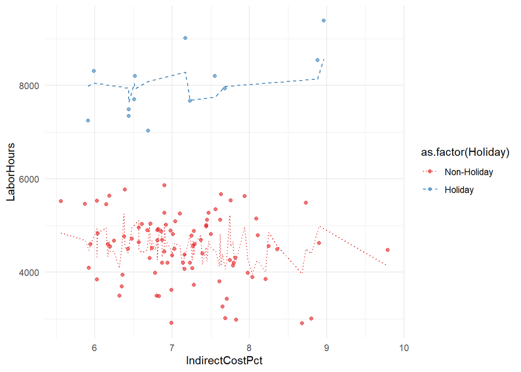

```r
library(ggplot2)
Retailer$fit <- fitted(Retailer_lm_no_int)
ggplot(Retailer, aes(x = IndirectCostPct, y = LaborHours, color = as.factor(Holiday))) +
  geom_point(alpha = 0.6) +
  geom_line(aes(y = fit, linetype = as.factor(Holiday))) +
  theme_minimal() +
  scale_color_brewer(palette = "Set1", labels = c("Non-Holiday", "Holiday")) +
  scale_linetype_manual(values = c("dotted", "dashed"), labels = c("Non-Holiday", "Holiday"))
```

c,

```r
Retailer_lm_full <- lm(LaborHours ~ Cases * IndirectCostPct * Holiday, data = Retailer)
summary(Retailer_lm_full)
```

```
##
## Call:
## lm(formula = LaborHours ~ Cases * IndirectCostPct * Holiday,
##     data = Retailer)
##
## Residuals:
##      Min       1Q   Median       3Q      Max
## -1549.11  -364.07    -7.27   445.04  1527.29
##
## Coefficients:
##                                 Estimate Std. Error t value Pr(>|t|)
## (Intercept)                    5.805e+03  2.837e+03   2.046   0.0435 *
## Cases                          1.117e-03  9.258e-03   0.121   0.9042
## IndirectCostPct               -3.202e+02  3.882e+02  -0.825   0.4115
## Holiday                       -1.735e+02  7.063e+03  -0.025   0.9804
## Cases:IndirectCostPct          3.253e-04  1.259e-03   0.258   0.7967
## Cases:Holiday                  3.770e-03  2.370e-02   0.159   0.8740
## IndirectCostPct:Holiday        4.541e+02  9.541e+02   0.476   0.6352
## Cases:IndirectCostPct:Holiday -3.017e-04  2.995e-03  -0.101   0.9200
## ---
## Signif. codes:  0 '***' 0.001 '**' 0.01 '*' 0.05 '.' 0.1 ' ' 1
##
## Residual standard error: 643.2 on 96 degrees of freedom
## Multiple R-squared:  0.7877, Adjusted R-squared:  0.7722
## F-statistic: 50.89 on 7 and 96 DF,  p-value: < 2.2e-16
```

```r
Retailer_lm_reduced <- lm(LaborHours ~ Cases + IndirectCostPct + Holiday + Cases:IndirectCostPct + Cases:Holiday + IndirectCostPct:Holiday, data = Retailer)

anova(Retailer_lm_reduced, Retailer_lm_full)
```

```
## Analysis of Variance Table
##
## Model 1: LaborHours ~ Cases + IndirectCostPct + Holiday + Cases:IndirectCostPct +
##     Cases:Holiday + IndirectCostPct:Holiday
## Model 2: LaborHours ~ Cases * IndirectCostPct * Holiday
##   Res.Df      RSS Df Sum of Sq      F Pr(>F)
## 1     97 39720558
## 2     96 39716360  1    4197.5 0.0101   0.92
```

```r
summary(Retailer_lm_reduced)
```

```
##
## Call:
## lm(formula = LaborHours ~ Cases + IndirectCostPct + Holiday +
##     Cases:IndirectCostPct + Cases:Holiday + IndirectCostPct:Holiday,
##     data = Retailer)
##
## Residuals:
##      Min       1Q   Median       3Q      Max
## -1548.79  -375.12    -5.95   444.46  1525.56
##
## Coefficients:
##                           Estimate Std. Error t value Pr(>|t|)
## (Intercept)              5.689e+03  2.577e+03   2.207   0.0296 *
## Cases                    1.506e-03  8.368e-03   0.180   0.8575
## IndirectCostPct         -3.042e+02  3.524e+02  -0.863   0.3901
## Holiday                  5.185e+02  1.630e+03   0.318   0.7510
## Cases:IndirectCostPct    2.720e-04  1.137e-03   0.239   0.8114
## Cases:Holiday            1.412e-03  3.730e-03   0.379   0.7058
## IndirectCostPct:Holiday  3.632e+02  3.069e+02   1.184   0.2395
## ---
## Signif. codes:  0 '***' 0.001 '**' 0.01 '*' 0.05 '.' 0.1 ' ' 1
##
## Residual standard error: 639.9 on 97 degrees of freedom
## Multiple R-squared:  0.7877, Adjusted R-squared:  0.7746
## F-statistic: 59.98 on 6 and 97 DF,  p-value: < 2.2e-16
```

```r
anova(Retailer_lm_no_int, Retailer_lm_full)
```

```
## Analysis of Variance Table
##
## Model 1: LaborHours ~ Cases + IndirectCostPct + Holiday
## Model 2: LaborHours ~ Cases * IndirectCostPct * Holiday
##   Res.Df      RSS Df Sum of Sq     F Pr(>F)
## 1    100 41672453
## 2     96 39716360  4   1956093 1.182 0.3237
```

The full model with all interactions was fitted, but the three-way interaction was nonsignificant (p = 0.920 > 0.10). The two-way interactions were also nonsignificant (p-values: 0.811, 0.706, 0.239 > 0.10). An overall F-test for adding interactions to the no-interaction model gave p = 0.324 > 0.10. Thus, the final reduced model is: Labor Hours ~ Cases + IndirectCostPct + Holiday

d,

```r
library(car)
vif(Retailer_lm_no_int, type = "predictor")
```

```
## VIFs computed for predictors
```

```
## [1] 1.050138 1.047214 1.004007
```

The VIF values are approximately 1.00 for const, 1.05 for Cases, 1.05 for IndirectCostPct, and 1.00 for Holiday. No predictors exhibit problematic collinearity (all VIF < 5).

e,

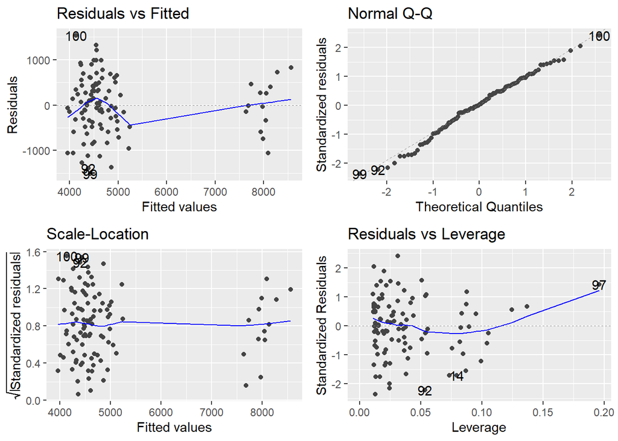

```r
library(ggfortify)
library(nortest)
autoplot(Retailer_lm_no_int)
```

```r
res <- residuals(Retailer_lm_no_int)
shapiro.test(res)
```

```
##
##  Shapiro-Wilk normality test
##
## data:  res
## W = 0.99049, p-value = 0.679
```

```r
ad.test(res)
```

```
##
##  Anderson-Darling normality test
##
## data:  res
## A = 0.29667, p-value = 0.5858
```

```r
lillie.test(res)
```

```
##
##  Lilliefors (Kolmogorov-Smirnov) normality test
##
## data:  res
## D = 0.066599, p-value = 0.3091
```

The assumptions appear reasonable. The residuals vs. fitted plot shows no obvious patterns, supporting linearity and equal variances. The normal Q-Q plot indicates approximate normality, with Shapiro-Wilk p-value = 0.679 > 0.05, Anderson-Darling statistic = 0.297, not rejecting normality.

f,

```r
predict(Retailer_lm_no_int, newdata = data.frame(Cases = 250000, IndirectCostPct = 5, Holiday = 0))
```

```
##        1
## 4671.155
```

```r
predict(Retailer_lm_no_int, newdata = data.frame(Cases = 300000, IndirectCostPct = 4, Holiday = 1))
```

```
##        1
## 8545.895
```

The predicted total labor hours for a non-holiday week with 250,000 cases shipped and 5% indirect costs is approximately 4671.16.

The predicted total labor hours for a holiday week with 300,000 cases shipped and 4% indirect costs is approximately 8545.9.